# final_project_part02_b

I-Ling Yeh

2020/11/2

## Load packages

```r
library(tidyverse)
```

```r
library(dplyr)
library(ggplot2)
library(visdat)
library(corrplot)
```

## Final project data

Reads in the data for the final project.

```r
data_url <- 'https://raw.githubusercontent.com/jyurko/INFSCI_2595_Fall_2020/master/HW/final_project/infsci_2595_final_project_data.csv'

df <- readr::read_csv(data_url, col_names = TRUE)
```

## Model training: Regression models-B

Separate the variables associated with Step 1 in Option B.

```r
step_1_df <- df %>% select(xA, xB, x01:x06, response_1) %>%
  mutate(xA = factor(xA),
         xB = factor(xB))
```

### Laplace Approximation approach

Using the Laplace Approximation approach. To set up the posterior function, then use laplace approximation to get the posterior mode and variance matrix.

```r
lm_logpost <- function(unknowns, my_info)
{
  # extract the beta parameters
  length_beta <- ncol(my_info$design_matrix) ## how many beta parmaeters????
  beta_vec <- unknowns[1:length_beta]

  # extract the unbounded log-transformed noise
  lik_varphi <- unknowns[length(unknowns)]

  ### back transfrom to the noise
  lik_sigma <- exp(lik_varphi)

  # extract the design matrix
  X <- my_info$design_matrix

  # calculate the mean trend using matrix operations
  # remember that beta_vec is a REGULAR VECTOR...
  mu <- X %*% as.matrix(beta_vec)

  # evaluate the log-likelihood, useful to convert the
  # mean trend from a column vector matrix type to a
  # REGULAR vector using as.numeric()
  log_lik <- sum(dnorm(x = my_info$yobs,
                       mean = as.numeric(mu),
                       sd = lik_sigma,
                       log = TRUE))

  # evaluate the log-prior
  log_prior_beta <- sum(dnorm(x = beta_vec,
                              mean = my_info$mu_beta,
                              sd = my_info$tau_beta,
                              log = TRUE))

  log_prior_sigma <- dexp(x = lik_sigma, rate = my_info$sigma_rate, log=TRUE)

  log_prior <- log_prior_beta + log_prior_sigma

  # account for the derivative adjustment
  log_derive_adjust <- lik_varphi

  # sum together
  log_lik + log_prior + log_derive_adjust
}
```

```r
my_laplace <- function(start_guess, logpost_func, ...)
{
  # code adapted from the `LearnBayes`` function `laplace()`
  fit <- optim(start_guess,
               logpost_func,
               gr = NULL,
               ...,
               method = "BFGS",
               hessian = TRUE,
               control = list(fnscale = -1, maxit = 1001))

  mode <- fit$par
  post_var_matrix <- -solve(fit$hessian)
  p <- length(mode)
  # we will discuss what int means in a few weeks...
  int <- p/2 * log(2 * pi) + 0.5 * log(det(post_var_matrix)) + logpost_func(mode, ...)
  # package all of the results into a list
  list(mode = mode,
       var_matrix = post_var_matrix,
       log_evidence = int,
       converge = ifelse(fit$convergence == 0,
                         "YES",
                         "NO"),
       iter_counts = as.numeric(fit$counts[1]))
}
```

Design matrix:

```r
Xmat03 <- model.matrix(response_1 ~ (.), data = step_1_df)
Xmat03%>% dim()
```

```
## [1] 2013   11
```

```r
Xmat04 <- model.matrix(response_1 ~ xA+xB+splines::ns(x01, df = 4)+splines::ns(x02, df = 4)+splines::ns(x03, df = 4)+x04+x05+x06, data = step_1_df)
Xmat04%>% dim()
```

```
## [1] 2013   20
```

Give the information to calculate the posterior:

```r
info_use_03 <- list(
  design_matrix = Xmat03,
  yobs = step_1_df$response_1,
  mu_beta = 0,
  tau_beta = 2,
  sigma_rate = 0.5
)
```

```r
info_use_04 <- list(
  design_matrix = Xmat04,
  yobs = step_1_df$response_1,
  mu_beta = 0,
  tau_beta = 2,
  sigma_rate = 0.5
)
```

```r
init_guess <- rep(-0.25, 12)

laplace_result_03 <- my_laplace(init_guess, lm_logpost, info_use_03)
laplace_result_03$mode
```

```
##  [1]  0.930830488  0.416575108 -2.714944173 -7.666477063 -1.633683301
##  [6]  0.929967087 -3.580259758  0.098647558  0.056189284  0.001948212
## [11]  1.137158897  1.353753717
```

```r
init_guess <- rep(-0.25, 21)

laplace_result_04 <- my_laplace(init_guess, lm_logpost, info_use_04)
laplace_result_04$mode
```

```
##  [1]  0.033634378  0.367368768 -2.317477839 -7.724891056 -1.165029108
##  [6]  1.052730075  1.376623363  5.691296781 11.041941621 -1.396714351
## [11] -5.865555841 -3.185572499 -6.283339605 -0.956757934 -0.405357084
## [16]  1.474938517  3.387594557  0.027661762 -0.002353525  0.014547218
## [21]  1.315335557
```

```r
generate_post_samples <- function(mvn_info, length_beta, num_samples)
{
  MASS::mvrnorm(n = num_samples,
                mu = mvn_info$mode ,
                Sigma = mvn_info$var_matrix ) %>%
    as.data.frame() %>% tibble::as_tibble() %>%
    purrr::set_names(c(sprintf("beta_%d", 0:(length_beta-1)), "varphi")) %>%
    mutate(sigma =  exp(varphi))
}
```

```r
set.seed(1231)
post_samples_03 <- generate_post_samples(laplace_result_03, 11, 1e4)
```

```r
set.seed(1231)
post_samples_04 <- generate_post_samples(laplace_result_04, 20, 1e4)
```

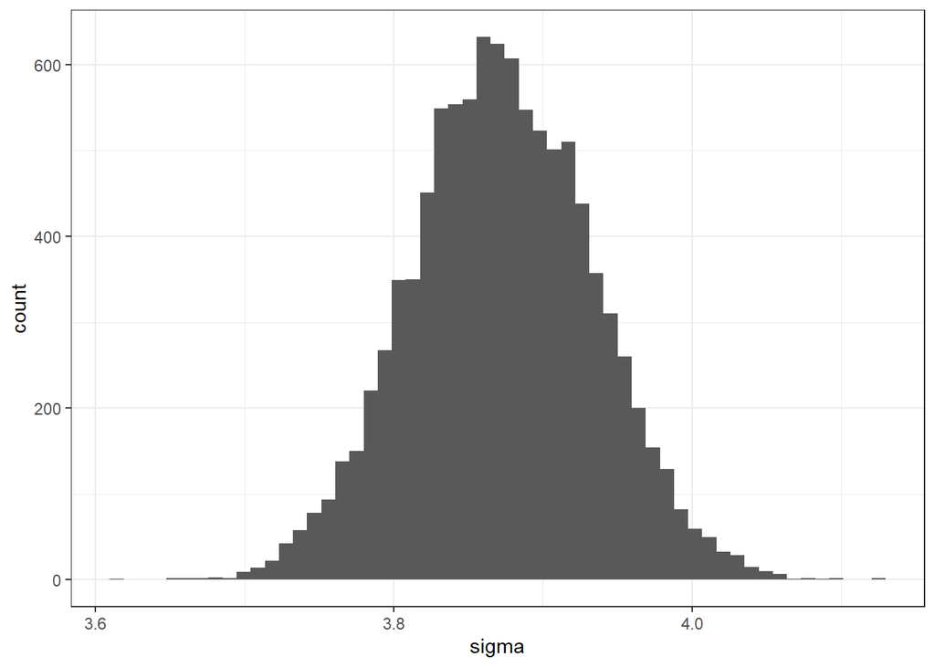

```r
post_samples_03 %>%
  ggplot(mapping = aes(x = sigma)) +
  geom_histogram(bins = 55) +
  theme_bw()
```

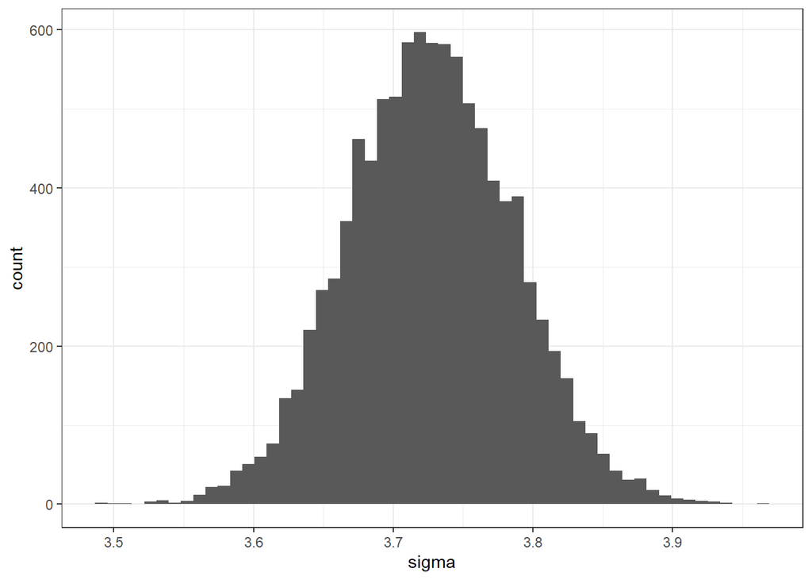

```r
post_samples_04 %>%
  ggplot(mapping = aes(x = sigma)) +
  geom_histogram(bins = 55) +
  theme_bw()
```

### rstanarm package

Use `rstanarm stan_lm`.

```r
#install.packages("rstanarm")
library(rstanarm)
stan_lm_03 <- stan_lm(response_1 ~ .,
                             data = step_1_df,
                             prior = R2(0.5),
                             seed = 12345)
stan_lm_03 %>% summary()
```

```
##
## Model Info:
##  function:     stan_lm
##  family:       gaussian [identity]
##  formula:      response_1 ~ .
##  algorithm:    sampling
##  sample:       4000 (posterior sample size)
##  priors:       see help('prior_summary')
##  observations: 2013
##  predictors:   11
##
## Estimates:
##                 mean   sd    10%   50%   90%
## (Intercept)   179.0   27.2 143.6 178.8 213.9
## xAA2            0.4    0.2   0.2   0.4   0.7
## xBB2           -2.4    0.2  -2.7  -2.4  -2.1
## xBB3           -7.8    0.2  -8.1  -7.8  -7.5
## xBB4           -1.3    0.3  -1.6  -1.3  -0.9
## x01             0.9    0.0   0.8   0.9   0.9
## x02            -4.1    0.2  -4.3  -4.1  -3.9
## x03             0.1    0.0   0.0   0.1   0.1
## x04             0.0    0.0   0.0   0.0   0.1
## x05             0.0    0.0   0.0   0.0   0.0
## x06            -0.2    0.2  -0.5  -0.2   0.1
## sigma           3.8    0.1   3.8   3.8   3.9
## log-fit_ratio   0.0    0.0   0.0   0.0   0.0
## R2              0.5    0.0   0.5   0.5   0.5
##
## Fit Diagnostics:
##            mean   sd   10%   50%   90%
## mean_PPD 0.5    0.1  0.3   0.5   0.7
##
## The mean_ppd is the sample average posterior predictive distribution of the outcome variable (for details see help('summary.stanreg')).
##
## MCMC diagnostics
##               mcse Rhat n_eff
## (Intercept)   0.6  1.0  2006
## xAA2          0.0  1.0  4108
## xBB2          0.0  1.0  5501
## xBB3          0.0  1.0  3849
## xBB4          0.0  1.0  6243
## x01           0.0  1.0  4429
## x02           0.0  1.0  3971
## x03           0.0  1.0  3947
## x04           0.0  1.0  3352
## x05           0.0  1.0  2979
## x06           0.0  1.0  2070
## sigma         0.0  1.0  4391
## log-fit_ratio 0.0  1.0  3237
## R2            0.0  1.0  3233
## mean_PPD      0.0  1.0  4176
## log-posterior 0.1  1.0   704
##
## For each parameter, mcse is Monte Carlo standard error, n_eff is a crude measure of effective sample size, and Rhat is the potential scale reduction factor on split chains (at convergence Rhat=1).
```

```r
stan_lm_04 <- stan_lm(response_1 ~ xA+xB+splines::ns(x01, df = 4)+splines::ns(x02, df = 4)+splines::ns(x03, df = 4)+x04+x05+x06, data = step_1_df, prior = R2(location = 0.5), seed = 12345)
stan_lm_04 %>% summary()
```

```
##
## Model Info:
##  function:     stan_lm
##  family:       gaussian [identity]
##  formula:      response_1 ~ xA + xB + splines::ns(x01, df = 4) + splines::ns(x02,
##     df = 4) + splines::ns(x03, df = 4) + x04 + x05 + x06
##  algorithm:    sampling
##  sample:       4000 (posterior sample size)
##  priors:       see help('prior_summary')
##  observations: 2013
##  predictors:   20
##
## Estimates:
##                             mean   sd    10%   50%   90%
## (Intercept)                 3.4   22.6 -25.6   3.7  32.4
## xAA2                        0.4    0.2   0.2   0.4   0.6
## xBB2                       -2.4    0.2  -2.8  -2.4  -2.1
## xBB3                       -7.7    0.2  -8.1  -7.7  -7.4
## xBB4                       -1.3    0.3  -1.6  -1.3  -0.9
## splines::ns(x01, df = 4)1   5.2    1.0   4.0   5.2   6.5
## splines::ns(x01, df = 4)2   3.4    0.7   2.5   3.4   4.3
## splines::ns(x01, df = 4)3  15.9    2.3  13.1  15.9  18.8
## splines::ns(x01, df = 4)4  14.3    0.9  13.2  14.3  15.4
## splines::ns(x02, df = 4)1  -3.9    0.8  -5.0  -3.9  -2.8
## splines::ns(x02, df = 4)2  -7.2    0.7  -8.0  -7.2  -6.3
## splines::ns(x02, df = 4)3  -9.5    2.0 -12.1  -9.5  -7.0
## splines::ns(x02, df = 4)4  -8.3    1.0  -9.6  -8.3  -7.0
## splines::ns(x03, df = 4)1   0.2    1.2  -1.3   0.2   1.7
## splines::ns(x03, df = 4)2  -0.1    0.8  -1.1  -0.1   1.0
## splines::ns(x03, df = 4)3   4.1    2.7   0.7   4.1   7.6
## splines::ns(x03, df = 4)4   4.8    1.2   3.2   4.7   6.3
## x04                         0.0    0.0   0.0   0.0   0.1
## x05                         0.0    0.0   0.0   0.0   0.0
## x06                         0.0    0.2  -0.3   0.0   0.3
## sigma                       3.7    0.1   3.6   3.7   3.8
## log-fit_ratio               0.0    0.0   0.0   0.0   0.0
## R2                          0.5    0.0   0.5   0.5   0.5
##
## Fit Diagnostics:
##            mean   sd   10%   50%   90%
```

[output cut: 18 more lines]

```
## splines::ns(x02, df = 4)4 0.0  1.0  7049
## splines::ns(x03, df = 4)1 0.0  1.0  4239
## splines::ns(x03, df = 4)2 0.0  1.0  4071
## splines::ns(x03, df = 4)3 0.0  1.0  4075
## splines::ns(x03, df = 4)4 0.0  1.0  5739
## x04                       0.0  1.0  4497
## x05                       0.0  1.0  4969
## x06                       0.0  1.0  2337
## sigma                     0.0  1.0  6474
## log-fit_ratio             0.0  1.0  4315
## R2                        0.0  1.0  4032
## mean_PPD                  0.0  1.0  4143
## log-posterior             0.2  1.0   646
##
## For each parameter, mcse is Monte Carlo standard error, n_eff is a crude measure of effective sample size, and Rhat is the potential scale reduction factor on split chains (at convergence Rhat=1).
```

First, I will use R-squared as performance matrix, thus `stan_lm_04` have higher R-squared.

```r
rstanarm::bayes_R2(stan_lm_03) %>% quantile(c(0.05, 0.5, 0.95))
```

```
##        5%       50%       95%
## 0.4718765 0.4941213 0.5161589
```

```r
rstanarm::bayes_R2(stan_lm_04) %>% quantile(c(0.05, 0.5, 0.95))
```

```
##        5%       50%       95%
## 0.5064411 0.5283173 0.5496586
```

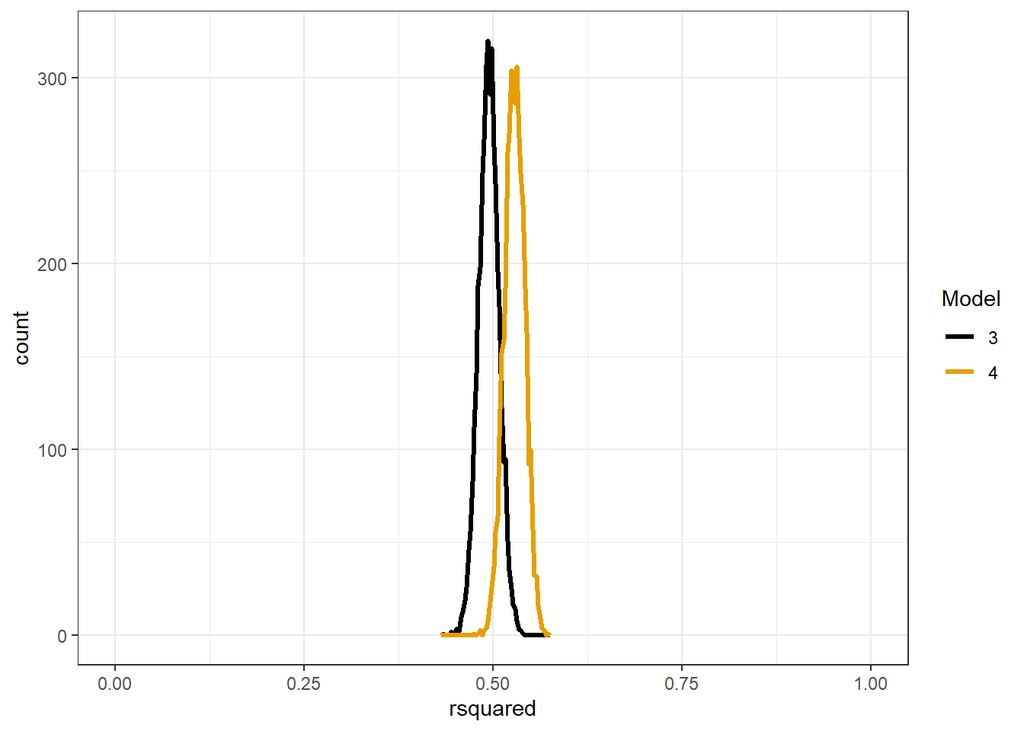

```r
purrr::map2_dfr(list(stan_lm_03, stan_lm_04),
                as.character(3:4),
                function(mod, mod_name){tibble::tibble(rsquared = bayes_R2(mod)) %>%
                    mutate(model_name = mod_name)}) %>%
  ggplot(mapping = aes(x = rsquared)) +
  geom_freqpoly(bins = 55,
                 mapping = aes(color = model_name),
                 size = 1.1) +
  coord_cartesian(xlim = c(0, 1)) +
  ggthemes::scale_color_colorblind("Model") +
  theme_bw()
```

Then I use Widely Applicable information Criterion that calculates the performance of the model and penalizes the performance of complex models based on the number of parameters. As the result, whatever the r-squared and WAIC, the `stan_lm_04` is the best model within two.

```r
stan_lm_03$waic <- waic(stan_lm_03)
stan_lm_04$waic <- waic(stan_lm_04)
my_models <- stanreg_list(stan_lm_03, stan_lm_04,
                          model_names = c("Linear additive", "basis function"))
loo_compare(my_models, criterion = "waic")
```

```
## Model comparison based on WAIC:
##                 elpd_diff se_diff
## basis function    0.0       0.0
## Linear additive -57.7      18.4
```

The coefficient posterior distributions in `stan_lm_04` look like Gaussians.

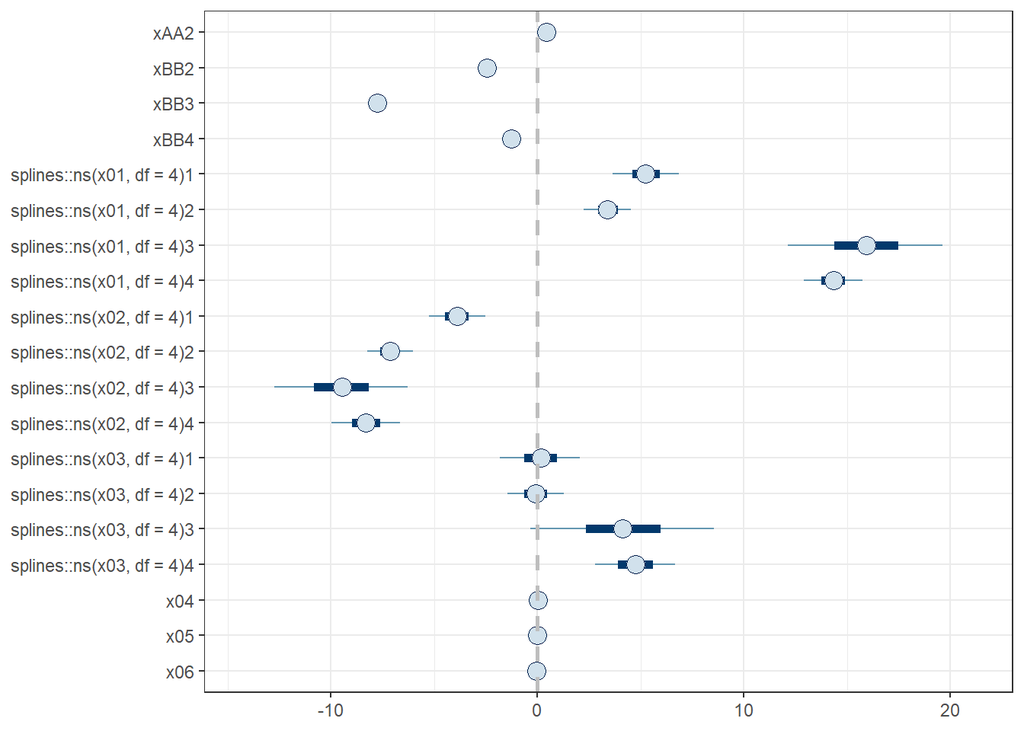

```r
plot(stan_lm_04, pars = names(stan_lm_04$coefficients)[-1]) +
  geom_vline(xintercept = 0, color = "grey", linetype = "dashed", size = 1.) +
  theme_bw()
```

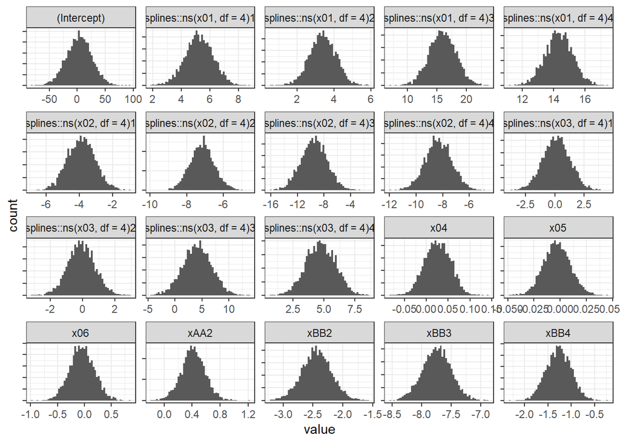

```r
as.data.frame(stan_lm_04) %>% tibble::as_tibble() %>%
  select(names(stan_lm_04$coefficients)) %>%
  tibble::rowid_to_column("post_id") %>%
  tidyr::gather(key = "key", value = "value", -post_id) %>%
  ggplot(mapping = aes(x = value)) +
  geom_histogram(bins = 55) +
  facet_wrap(~key, scales = "free") +
  theme_bw() +
  theme(axis.text.y = element_blank())
```

For my best model, `stan_lm_04`, I study the uncertainty in the noise.

```r
as.data.frame(stan_lm_04) %>% tibble::as_tibble() %>%
  select(sigma) %>%
  pull() %>%
  quantile(c(0.05, 0.5, 0.95))
```

```
##       5%      50%      95%
## 3.616925 3.709611 3.812097
```

In the part2-a, we fit a simple linear model for `response_1`. Use `lm()` to fit linear models with all step1 inputs.

```r
lm_04 <- lm(response_1 ~ xA+xB+splines::ns(x01, df = 4)+splines::ns(x02, df = 4)+splines::ns(x03, df = 4)+x04+x05+x06, step_1_df)
```

Summarize the model results with the `summary()` function.

```r
lm_04 %>% summary()
```

```
##
## Call:
## lm(formula = response_1 ~ xA + xB + splines::ns(x01, df = 4) +
##     splines::ns(x02, df = 4) + splines::ns(x03, df = 4) + x04 +
##     x05 + x06, data = step_1_df)
##
## Residuals:
##      Min       1Q   Median       3Q      Max
## -22.8097  -1.9224  -0.0148   1.9057  18.4712
##
## Coefficients:
##                            Estimate Std. Error t value Pr(>|t|)
## (Intercept)                2.529664  22.830068   0.111   0.9118
## xAA2                       0.421810   0.167998   2.511   0.0121 *
## xBB2                      -2.464165   0.245289 -10.046  < 2e-16 ***
## xBB3                      -7.826777   0.236342 -33.116  < 2e-16 ***
## xBB4                      -1.283173   0.265400  -4.835 1.43e-06 ***
## splines::ns(x01, df = 4)1  5.303074   0.971188   5.460 5.34e-08 ***
## splines::ns(x01, df = 4)2  3.420436   0.702766   4.867 1.22e-06 ***
## splines::ns(x01, df = 4)3 16.110024   2.255446   7.143 1.28e-12 ***
## splines::ns(x01, df = 4)4 14.485743   0.877413  16.510  < 2e-16 ***
## splines::ns(x02, df = 4)1 -3.906590   0.846261  -4.616 4.16e-06 ***
## splines::ns(x02, df = 4)2 -7.219413   0.665284 -10.852  < 2e-16 ***
## splines::ns(x02, df = 4)3 -9.555626   1.998848  -4.781 1.88e-06 ***
## splines::ns(x02, df = 4)4 -8.389939   0.987988  -8.492  < 2e-16 ***
## splines::ns(x03, df = 4)1  0.136698   1.199049   0.114   0.9092
## splines::ns(x03, df = 4)2 -0.092215   0.843564  -0.109   0.9130
## splines::ns(x03, df = 4)3  4.137396   2.729516   1.516   0.1297
## splines::ns(x03, df = 4)4  4.789060   1.172546   4.084 4.60e-05 ***
## x04                        0.025767   0.030038   0.858   0.3911
## x05                       -0.003158   0.012623  -0.250   0.8025
## x06                       -0.036679   0.231517  -0.158   0.8741
## ---
## Signif. codes:  0 '***' 0.001 '**' 0.01 '*' 0.05 '.' 0.1 ' ' 1
##
## Residual standard error: 3.708 on 1993 degrees of freedom
## Multiple R-squared:  0.5339, Adjusted R-squared:  0.5295
## F-statistic: 120.2 on 19 and 1993 DF,  p-value: < 2.2e-16
```

We compare the maximum likelihood estimate (MLE) on the noise, $\sigma$ and the posterior uncertainty on $\sigma$.

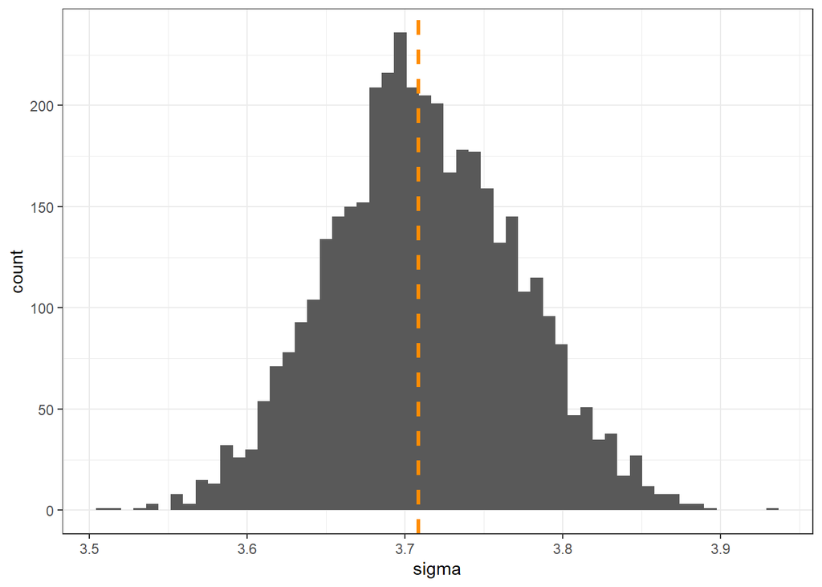

```r
as.data.frame(stan_lm_04) %>% tibble::as_tibble() %>%
  ggplot(mapping = aes(x = sigma)) +
  geom_histogram(bins = 55) +
  geom_vline(xintercept = stats::sigma(lm_04),
             color = "darkorange", linetype = "dashed", size = 1.1) +
  theme_bw()
```